# Google data analytics certificate case study: Bellabeat fitness tech

KP

last updated 8/21/2021

## Introduction and background

This is an R Markdown document with R script to view, process, clean, and analyze data for a Google data analytics certificate case study. I utilized CRAN packages ‘tidyverse’, ‘here’, ‘skimr’, ‘janitor’, and ‘GGally’.

## Business task

Analyze smart device usage data to gain insight into how consumers use non-Bellabeat smart devices and develop recommendations for Bellabeat products. For a summary of insights and recommendations, scroll to the bottom.

## Data and limitations

This case study uses [FitBit Fitness Tracker Data](https://www.kaggle.com/arashnic/fitbit) (CC0: Public Domain, dataset made available by [Mobius](https://www.kaggle.com/arashnic) via Kaggle). This Kaggle data set contains personal fitness tracker from thirty Fitbit users, generated by respondents to a survey distributed via Amazon Mechanical Turk between 03.12.2016-05.12.2016. Variation in output represents use of different types of trackers and individual self-tracking behaviors and preferences.

Notes on limitations:

- The dataset is not representative of the general U.S. population; sets are collected only from Fitbit users who voluntarily completed a survey.
- Our sample size is too small to develop meaningful statistical predictions of consumer behavior. Instead, we will attempt to identify general trends and gain insight to guide further exploration and improve Bellabeat products.

## Installing and loading the tidyverse package

```r
# install.packages('tidyverse')
  library(tidyverse)
```

## Loading CSV files

Creates data frames for daily activity and sleep data.

```r
daily_activity <- read.csv(
"~/CSV Data/fitbit data/Fitabase Data 4.12.16-5.12.16/dailyActivity_merged.csv")

sleep_day <- read.csv(
"~/CSV Data/fitbit data/Fitabase Data 4.12.16-5.12.16/sleepDay_merged.csv")

weight_log <- read.csv(
"~/CSV Data/fitbit data/Fitabase Data 4.12.16-5.12.16/weightLogInfo_merged.csv")
```

## Exploring key tables

View top rows of data frames.

```r
head(daily_activity)
```

```
##           Id ActivityDate TotalSteps TotalDistance TrackerDistance
## 1 1503960366    4/12/2016      13162          8.50            8.50
## 2 1503960366    4/13/2016      10735          6.97            6.97
## 3 1503960366    4/14/2016      10460          6.74            6.74
## 4 1503960366    4/15/2016       9762          6.28            6.28
## 5 1503960366    4/16/2016      12669          8.16            8.16
## 6 1503960366    4/17/2016       9705          6.48            6.48
##   LoggedActivitiesDistance VeryActiveDistance ModeratelyActiveDistance
## 1                        0               1.88                     0.55
## 2                        0               1.57                     0.69
## 3                        0               2.44                     0.40
## 4                        0               2.14                     1.26
## 5                        0               2.71                     0.41
## 6                        0               3.19                     0.78
##   LightActiveDistance SedentaryActiveDistance VeryActiveMinutes
## 1                6.06                       0                25
## 2                4.71                       0                21
## 3                3.91                       0                30
## 4                2.83                       0                29
## 5                5.04                       0                36
## 6                2.51                       0                38
##   FairlyActiveMinutes LightlyActiveMinutes SedentaryMinutes Calories
## 1                  13                  328              728     1985
## 2                  19                  217              776     1797
## 3                  11                  181             1218     1776
## 4                  34                  209              726     1745
## 5                  10                  221              773     1863
## 6                  20                  164              539     1728
```

```r
head(sleep_day)
```

```
##           Id              SleepDay TotalSleepRecords TotalMinutesAsleep
## 1 1503960366 4/12/2016 12:00:00 AM                 1                327
## 2 1503960366 4/13/2016 12:00:00 AM                 2                384
## 3 1503960366 4/15/2016 12:00:00 AM                 1                412
## 4 1503960366 4/16/2016 12:00:00 AM                 2                340
## 5 1503960366 4/17/2016 12:00:00 AM                 1                700
## 6 1503960366 4/19/2016 12:00:00 AM                 1                304
##   TotalTimeInBed
## 1            346
## 2            407
## 3            442
## 4            367
## 5            712
## 6            320
```

View column names.

```r
colnames(daily_activity)
```

```
##  [1] "Id"                       "ActivityDate"
##  [3] "TotalSteps"               "TotalDistance"
##  [5] "TrackerDistance"          "LoggedActivitiesDistance"
##  [7] "VeryActiveDistance"       "ModeratelyActiveDistance"
##  [9] "LightActiveDistance"      "SedentaryActiveDistance"
## [11] "VeryActiveMinutes"        "FairlyActiveMinutes"
## [13] "LightlyActiveMinutes"     "SedentaryMinutes"
## [15] "Calories"
```

```r
colnames(sleep_day)
```

```
## [1] "Id"                 "SleepDay"           "TotalSleepRecords"
## [4] "TotalMinutesAsleep" "TotalTimeInBed"
```

Note: Both data sets contain ‘Id’ as a field. We can use this to merge the frames later.

## Viewing summary statistics for familiarization

How many unique participants are there in each dataframe?

```r
n_distinct(daily_activity$Id)
```

```
## [1] 33
```

```r
n_distinct(sleep_day$Id)
```

```
## [1] 24
```

Note: sleep_day has 24 unique ‘Id’ values but daily_activity has 33. This may indicate that some respondents chose not to submit, or don’t record, sleep activity data.

View the number of observations and summary statistics for each data frame.

```r
nrow(daily_activity)
```

```
## [1] 940
```

```r
nrow(sleep_day)
```

```
## [1] 413
```

```r
daily_activity %>%
  select(TotalSteps,
         TotalDistance,
         SedentaryMinutes,
         Calories) %>%
  summary()
```

```
##    TotalSteps    TotalDistance    SedentaryMinutes    Calories
##  Min.   :    0   Min.   : 0.000   Min.   :   0.0   Min.   :   0
##  1st Qu.: 3790   1st Qu.: 2.620   1st Qu.: 729.8   1st Qu.:1828
##  Median : 7406   Median : 5.245   Median :1057.5   Median :2134
##  Mean   : 7638   Mean   : 5.490   Mean   : 991.2   Mean   :2304
##  3rd Qu.:10727   3rd Qu.: 7.713   3rd Qu.:1229.5   3rd Qu.:2793
##  Max.   :36019   Max.   :28.030   Max.   :1440.0   Max.   :4900
```

Notes:

- median steps for users are 7406
- There are a few low outliers with zero-values. Our data set description stated variations are due to user preferences and behaviors. Maybe the user forgot or chose not to wear the device, or maybe the device wasn’t charged.

```r
sleep_day_v2 <- sleep_day %>%
  mutate('TotalHoursAsleep' = TotalMinutesAsleep/60, 'TotalHoursInBed' =
  TotalTimeInBed/60, .keep = "unused")

sleep_day_v2 %>%
  select(TotalSleepRecords,
  TotalHoursAsleep,
  TotalHoursInBed) %>%
  summary()
```

```
##  TotalSleepRecords TotalHoursAsleep  TotalHoursInBed
##  Min.   :1.000     Min.   : 0.9667   Min.   : 1.017
##  1st Qu.:1.000     1st Qu.: 6.0167   1st Qu.: 6.717
##  Median :1.000     Median : 7.2167   Median : 7.717
##  Mean   :1.119     Mean   : 6.9911   Mean   : 7.644
##  3rd Qu.:1.000     3rd Qu.: 8.1667   3rd Qu.: 8.767
##  Max.   :3.000     Max.   :13.2667   Max.   :16.017
```

Notes:

- Converted time asleep and time in bed to hours to make values more intuitive.
- Data indicates at least one respondent got <1 hour of sleep at least one night, another observation indicates a respondent spent over 16 hours in bed. These values deserve further investigation.

## Cleaning our data

Calculate a new column for TotalMinutes to quickly see if users wore their charged device for the entire day.

```r
daily_activity_v2 <- daily_activity %>%
  mutate(TotalMinutes = VeryActiveMinutes + FairlyActiveMinutes +
  LightlyActiveMinutes + SedentaryMinutes)
```

```r
daily_activity_v2 %>%
  select(TotalMinutes) %>%
  summary()
```

```
##   TotalMinutes
##  Min.   :   2.0
##  1st Qu.: 989.8
##  Median :1440.0
##  Mean   :1218.8
##  3rd Qu.:1440.0
##  Max.   :1440.0
```

Note: Some observations appear to indicate a device was either not worn or not charged for the entire 24-hour (1440 minute) period. Run a filter for observations <= 2 hours of sleep or <= 720 total minutes (half of one day) after combining data frames to see all associated values in one place.

```r
# install.packages("here")
# install.packages("skimr")
# install.packages("janitor")

library(here)
library(skimr)
library(janitor)
```

View a more detailed data summary.

```r
skim_without_charts(daily_activity_v2)
```

Data summary

| Name | daily_activity_v2 |
| --- | --- |
| Number of rows | 940 |
| Number of columns | 16 |
| _______________________ |  |
| Column type frequency: |  |
| character | 1 |
| numeric | 15 |
| ________________________ |  |
| Group variables | None |

**Variable type: character**

| skim_variable | n_missing | complete_rate | min | max | empty | n_unique | whitespace |
| --- | --- | --- | --- | --- | --- | --- | --- |
| ActivityDate | 0 | 1 | 8 | 9 | 0 | 31 | 0 |

**Variable type: numeric**

| skim_variable | n_missing | complete_rate | mean | sd | p0 | p25 | p50 | p75 | p100 |
| --- | --- | --- | --- | --- | --- | --- | --- | --- | --- |
| Id | 0 | 1 | 4.855407e+09 | 2.424805e+09 | 1503960366 | 2.320127e+09 | 4.445115e+09 | 6.962181e+09 | 8.877689e+09 |
| TotalSteps | 0 | 1 | 7.637910e+03 | 5.087150e+03 | 0 | 3.789750e+03 | 7.405500e+03 | 1.072700e+04 | 3.601900e+04 |
| TotalDistance | 0 | 1 | 5.490000e+00 | 3.920000e+00 | 0 | 2.620000e+00 | 5.240000e+00 | 7.710000e+00 | 2.803000e+01 |
| TrackerDistance | 0 | 1 | 5.480000e+00 | 3.910000e+00 | 0 | 2.620000e+00 | 5.240000e+00 | 7.710000e+00 | 2.803000e+01 |
| LoggedActivitiesDistance | 0 | 1 | 1.100000e-01 | 6.200000e-01 | 0 | 0.000000e+00 | 0.000000e+00 | 0.000000e+00 | 4.940000e+00 |
| VeryActiveDistance | 0 | 1 | 1.500000e+00 | 2.660000e+00 | 0 | 0.000000e+00 | 2.100000e-01 | 2.050000e+00 | 2.192000e+01 |
| ModeratelyActiveDistance | 0 | 1 | 5.700000e-01 | 8.800000e-01 | 0 | 0.000000e+00 | 2.400000e-01 | 8.000000e-01 | 6.480000e+00 |
| LightActiveDistance | 0 | 1 | 3.340000e+00 | 2.040000e+00 | 0 | 1.950000e+00 | 3.360000e+00 | 4.780000e+00 | 1.071000e+01 |
| SedentaryActiveDistance | 0 | 1 | 0.000000e+00 | 1.000000e-02 | 0 | 0.000000e+00 | 0.000000e+00 | 0.000000e+00 | 1.100000e-01 |
| VeryActiveMinutes | 0 | 1 | 2.116000e+01 | 3.284000e+01 | 0 | 0.000000e+00 | 4.000000e+00 | 3.200000e+01 | 2.100000e+02 |
| FairlyActiveMinutes | 0 | 1 | 1.356000e+01 | 1.999000e+01 | 0 | 0.000000e+00 | 6.000000e+00 | 1.900000e+01 | 1.430000e+02 |
| LightlyActiveMinutes | 0 | 1 | 1.928100e+02 | 1.091700e+02 | 0 | 1.270000e+02 | 1.990000e+02 | 2.640000e+02 | 5.180000e+02 |
| SedentaryMinutes | 0 | 1 | 9.912100e+02 | 3.012700e+02 | 0 | 7.297500e+02 | 1.057500e+03 | 1.229500e+03 | 1.440000e+03 |
| Calories | 0 | 1 | 2.303610e+03 | 7.181700e+02 | 0 | 1.828500e+03 | 2.134000e+03 | 2.793250e+03 | 4.900000e+03 |
| TotalMinutes | 0 | 1 | 1.218750e+03 | 2.659300e+02 | 2 | 9.897500e+02 | 1.440000e+03 | 1.440000e+03 | 1.440000e+03 |

```r
skim_without_charts(sleep_day)
```

Data summary

| Name | sleep_day |
| --- | --- |
| Number of rows | 413 |
| Number of columns | 5 |
| _______________________ |  |
| Column type frequency: |  |
| character | 1 |
| numeric | 4 |
| ________________________ |  |
| Group variables | None |

**Variable type: character**

| skim_variable | n_missing | complete_rate | min | max | empty | n_unique | whitespace |
| --- | --- | --- | --- | --- | --- | --- | --- |
| SleepDay | 0 | 1 | 20 | 21 | 0 | 31 | 0 |

**Variable type: numeric**

| skim_variable | n_missing | complete_rate | mean | sd | p0 | p25 | p50 | p75 | p100 |
| --- | --- | --- | --- | --- | --- | --- | --- | --- | --- |
| Id | 0 | 1 | 5.000979e+09 | 2.06036e+09 | 1503960366 | 3977333714 | 4702921684 | 6962181067 | 8792009665 |
| TotalSleepRecords | 0 | 1 | 1.120000e+00 | 3.50000e-01 | 1 | 1 | 1 | 1 | 3 |
| TotalMinutesAsleep | 0 | 1 | 4.194700e+02 | 1.18340e+02 | 58 | 361 | 433 | 490 | 796 |
| TotalTimeInBed | 0 | 1 | 4.586400e+02 | 1.27100e+02 | 61 | 403 | 463 | 526 | 961 |

Notes:

## Merging data frames

```r
library(lubridate)
sleep_day_v3 <- sleep_day_v2 %>%
  mutate(NewSleepDay = substr(sleep_day_v2$SleepDay, 1, 9))
```

```r
sleep_day_v3$ActivityDate <- trimws(sleep_day_v3$NewSleepDay, which = c("both"),
  whitespace = " ")

sleep_day_v4 <- sleep_day_v3 %>%
  select(-NewSleepDay, -SleepDay)
```

```r
sleep_and_activity <- full_join(daily_activity_v2, sleep_day_v4, all = TRUE)
```

Some of the values in sleep_and_activity have SedentaryMinutes values of 1440 minutes, a value for calories, and no other data. I assume these values represent days where Fitbits collected data but were not worn by users, resulting in a basal metabolic rate caloric calculation and a reading of ‘sedentary’ for the entire 24 hours. I will remove these observations to clean the data set.

```r
sleep_and_activity_v2 <- filter(sleep_and_activity, SedentaryMinutes!=1440)
```

```r
low_outliers <- sleep_and_activity_v2 %>%
  filter(TotalHoursAsleep <= 2 | TotalMinutes <= 720)
head(low_outliers)
```

```
##           Id ActivityDate TotalSteps TotalDistance TrackerDistance
## 1 1644430081    4/29/2016       3176          2.31            2.31
## 2 1844505072    4/15/2016       3844          2.54            2.54
## 3 1844505072    4/30/2016       4014          2.67            2.67
## 4 1844505072     5/1/2016       2573          1.70            1.70
## 5 1844505072    5/12/2016          0          0.00            0.00
## 6 2026352035    5/12/2016       8891          5.51            5.51
##   LoggedActivitiesDistance VeryActiveDistance ModeratelyActiveDistance
## 1                        0                  0                     0.00
## 2                        0                  0                     0.00
## 3                        0                  0                     0.00
## 4                        0                  0                     0.26
## 5                        0                  0                     0.00
## 6                        0                  0                     0.00
##   LightActiveDistance SedentaryActiveDistance VeryActiveMinutes
```

[output cut: 20 more lines]

Note: There are a few values where TotalMinutes are less than 60 and the associated calorie count is high. This might be indicative of users who wore their Fitbit only for the duration of a single workout that day. The vast majority of observations seem to indicate that our survey respondents are wearing their Fitbits for long duration and consistently, rather than using them to track isolated workouts.

Let’s explore this idea:

```r
(nrow(sleep_and_activity_v2[sleep_and_activity_v2$TotalMinutes > 720, ])/
   nrow(sleep_and_activity_v2)) * 100
```

```
## [1] 97.10648
```

Notes:

- Respondents used their Fitbits for *more than half the day in 97% of reported observations.*
- These users may benefit from a combined subscription service and app with a dashboard for viewing and managing data and receiving health recommendations.
- Performing additional surveys with questions about user behavior could expand this insight.

```r
sleep_and_activity_v3 <- sleep_and_activity_v2 %>% mutate(TotalActiveMinutes =
  VeryActiveMinutes + FairlyActiveMinutes + LightlyActiveMinutes)
```

## Plotting explorations and analysis

```r
sleep_and_activity_v4 <- sleep_and_activity_v3 %>%
  mutate('TotalMinutesAsleep' = TotalHoursAsleep*60, 'TotalMinutesInBed' =
  TotalHoursInBed*60, .keep = "unused")
```

```r
# install.packages("GGally")
library(GGally)
```

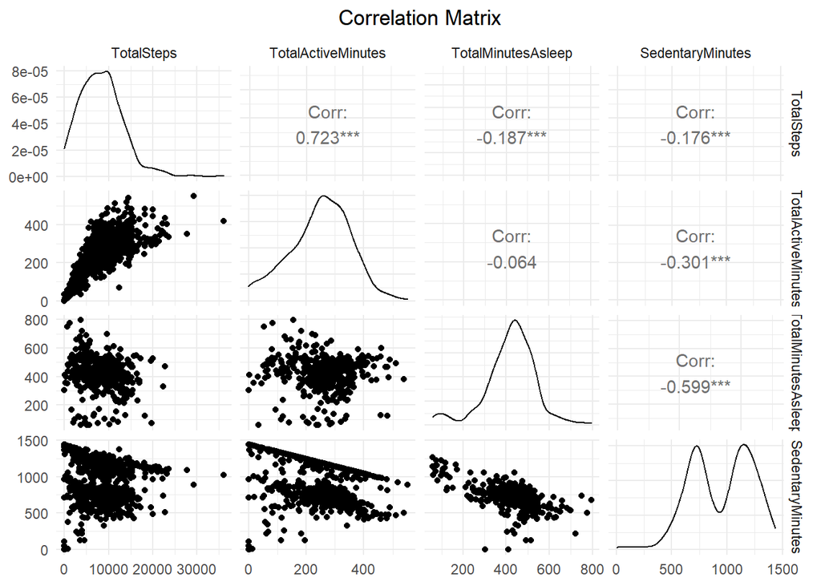

```r
segment_sleep_steps_activity <- sleep_and_activity_v4 %>% select(TotalSteps,
  TotalActiveMinutes, TotalMinutesAsleep, SedentaryMinutes)

ggpairs(
  segment_sleep_steps_activity,
  title = 'Correlation Matrix',
  axisLabels = c("show"),
  labeller = "label_value",
  proportions = "auto",
  shape = ".",
  cardinality_threshold = NULL
  ) + theme_minimal()+
  theme(plot.title = element_text(hjust = 0.5))
```

Notes:

- Correlation values are Pearson correlation coefficients
- TotalSteps and TotalActiveMinutes are positively correlated.
- TotalMinutesAsleep and SedentaryMinutes are negatively correlated. This means that as time spent sedentary goes up time spent sleeping generally goes down, but it does not prove causation.

Focus on the two strongest correlations among the analyzed variables.

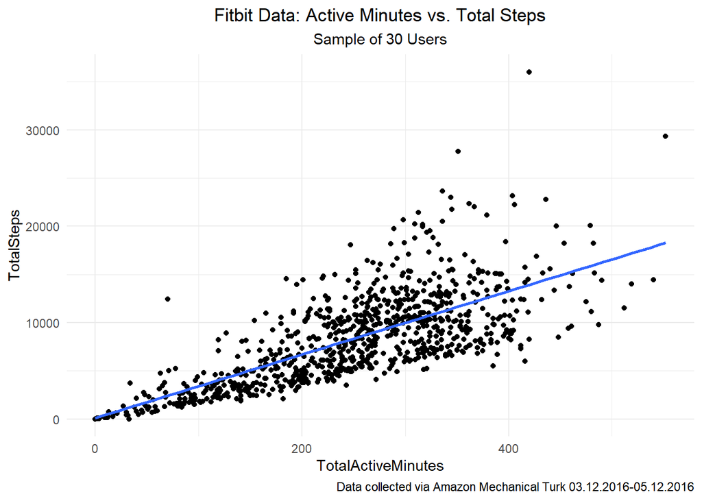

```r
sleep_and_activity_v4 %>%
  ggplot(mapping = aes(x=TotalActiveMinutes, y=TotalSteps)) + geom_point() +
  geom_smooth(method='lm', se=FALSE) + theme_minimal() +
  labs(title="Fitbit Data: Active Minutes vs. Total Steps", subtitle=
      "Sample of 30 Users", caption =
      "Data collected via Amazon Mechanical Turk 03.12.2016-05.12.2016") +
  theme(plot.title = element_text(hjust = 0.5), plot.subtitle =
        element_text(hjust = 0.5))
```

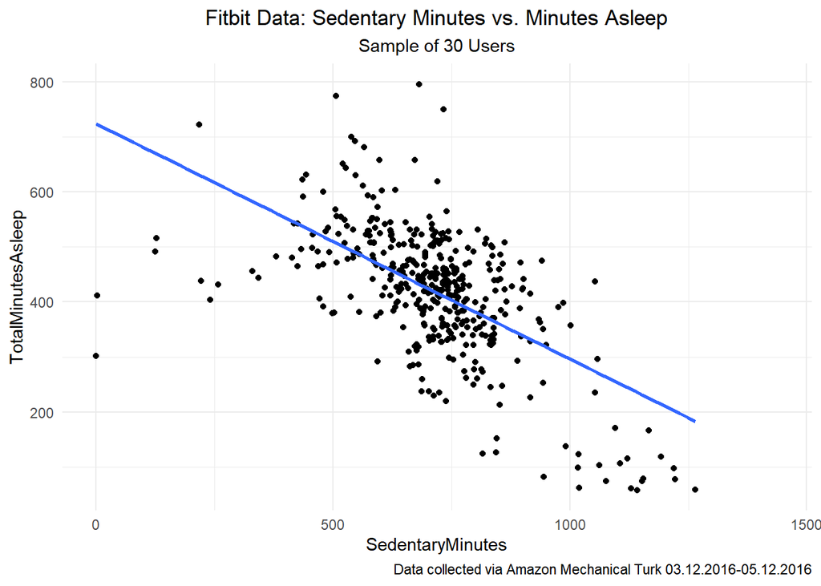

```r
sleep_and_activity_v4 %>%
  ggplot(mapping = aes(x=SedentaryMinutes, y=TotalMinutesAsleep)) +
  geom_point() + geom_smooth(method="lm", se=FALSE) + theme_minimal() +
  labs(title="Fitbit Data: Sedentary Minutes vs. Minutes Asleep", subtitle=
  "Sample of 30 Users",
  caption="Data collected via Amazon Mechanical Turk 03.12.2016-05.12.2016")+
  theme(plot.title = element_text(hjust = 0.5), plot.subtitle =
  element_text(hjust = 0.5))
```

Observe the relationship between sedentary time, sleep time, and BMI for respondents after merging in the weight_log data frame.

```r
bmi_data <- weight_log %>%
  group_by(Id) %>%
  summarize(BMI = mean(BMI))

activity_bmi_sleep <- full_join(sleep_and_activity_v4, bmi_data)
```

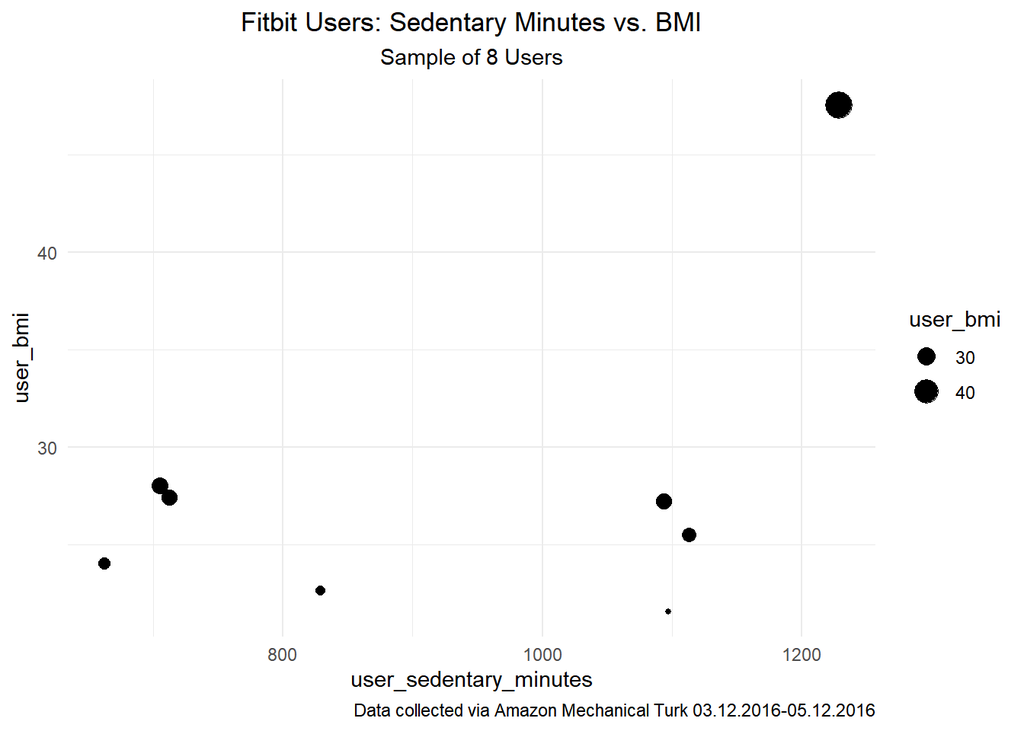

```r
unique_id_bmi <- activity_bmi_sleep %>%
  select(Id, BMI, SedentaryMinutes) %>%
  group_by(Id) %>%
  summarize(user_bmi = mean(BMI), user_sedentary_minutes = mean(SedentaryMinutes)) %>%
  na.omit()

unique_id_bmi %>%
  ggplot() + geom_point(mapping=aes(x=user_sedentary_minutes, y=user_bmi,
                                    size=user_bmi)) +theme_minimal() +
  labs(title="Fitbit Users: Sedentary Minutes vs. BMI", subtitle=
  "Sample of 8 Users",
  caption="Data collected via Amazon Mechanical Turk 03.12.2016-05.12.2016") +
  theme(plot.title = element_text(hjust = 0.5), plot.subtitle =
  element_text(hjust = 0.5))
```

Note: It turns out there are only 8 unique Id’s with corresponding BMI values in the survey results. This sample is probably too small to gain meaningful insight.

Earlier analysis indicated users wore devices for 720 or more minutes out of 1440 minutes in 97% of our survey observations. Expand that idea with a histogram counting unique user Ids per bin, where bins group mean daily Fitbit utilization proportion values.

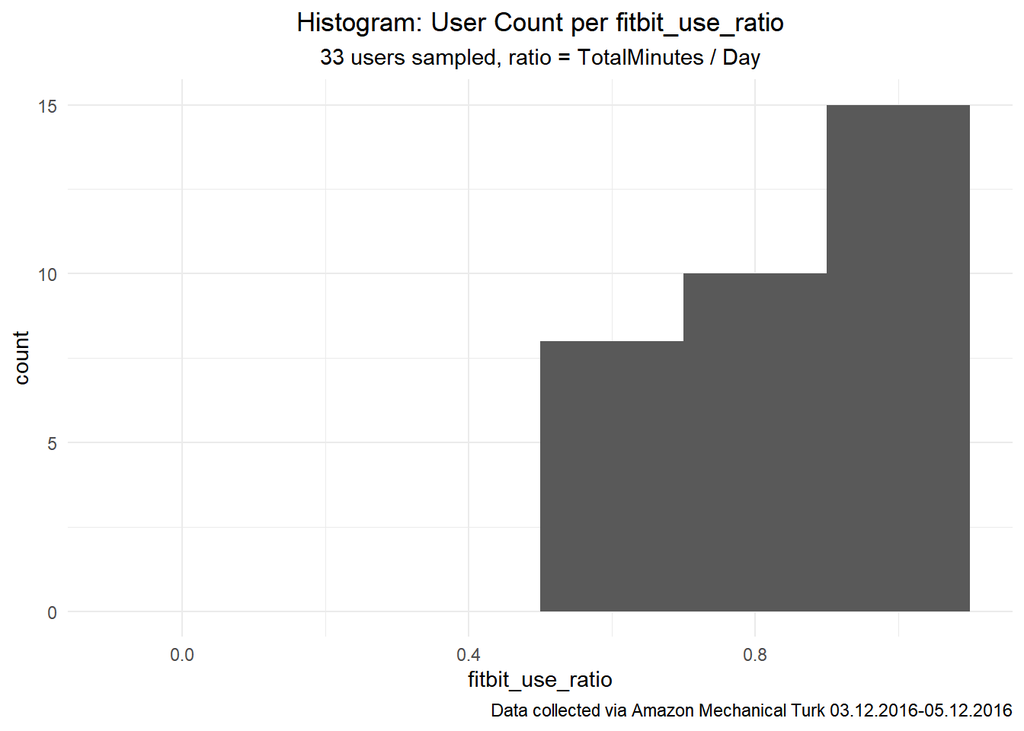

```r
use_data_histogram <- activity_bmi_sleep %>%
  select(Id, TotalMinutes, TotalActiveMinutes) %>%
  group_by(Id) %>%
  summarize(fitbit_use_ratio = mean(TotalMinutes)/1440,
  mean_active_minutes = mean(TotalActiveMinutes))

ggplot(data=use_data_histogram) + geom_histogram(mapping=aes
  (x=fitbit_use_ratio), binwidth = 0.2) + expand_limits(x=0) +
  theme_minimal() + labs(title=
  "Histogram: User Count per fitbit_use_ratio",
  subtitle="33 users sampled, ratio = TotalMinutes / Day",
  caption="Data collected via Amazon Mechanical Turk 03.12.2016-05.12.2016") +
  theme(plot.title = element_text(hjust = 0.5), plot.subtitle =
  element_text(hjust = 0.5))
```

Note: The majority of survey respondents used their Fitbits for more than half the day, so the trend *among those surveyed* is to regularly and consistently wear their Fitbits and maintain them charged.

## Summary of insights

- Total steps and total active minutes are relatively strongly correlated. It makes sense that someone who walks more would spend more minutes being active and vice versa, but this correlation does not prove causation and there may be a confounding variable affecting both values. Total active minutes includes lightly active, fairly active, and very active minutes.
- Sedentary minutes and sleep time are negatively correlated. This does not prove causation, but we can create hypotheses to test for a causal relationship. Possible hypotheses include:
  1. People who spend more time sedentary spend less time active because the lack of physical activity induces physiological changes resulting in less sleep.
  2. People who sleep less feel less energetic and are therefore less motivated to perform physical activity, resulting in reduced daily active minutes.
- Surveyed users utilize their Fitbits consistently throughout the day and regularly across days. Note this data is collected from voluntary survey participants so our sample may be biased towards users who use their Fitbits regularly.